# Data Structure

## Vectors

## Data types in R

A **vector** is an ordered sequence of data. `R` has many types of data, for example:

- `logical`: logical (`TRUE` or `FALSE`)
- `integer`: whole numbers, \(\mathbb Z\)
- `numeric`: real numbers, \(\mathbb R\)
- `complex`: complex numbers, \(\mathbb C\)
- `character`: words

In the vectors of `R`, all their objects must be of the same type: all numbers, all words, etc. When we want to use vectors formed by objects of different types, we will have to use **generalized lists**, ‘lists’ that we will see at the end of the topic.

## Basic

- `c()`: to define a vector
- `scan()`: to define a vector
- `fix(x)`: to visually modify the vector \(x\)
- `rep(a, n)`: to define a constant vector that contains the data \(a\) repeated \(n\) times

```r
c(1,2,3)
```

```
[1] 1 2 3
```

```r
rep("Tono",5)
```

```
[1] "Tono" "Tono" "Tono" "Tono" "Tono"
```

## scan() function

This functions also work with URL with text files

**Example**

This is an example of how to create a vector that contains 3 copies of 1 9 9 8 0 7 2 6 with the scan function:

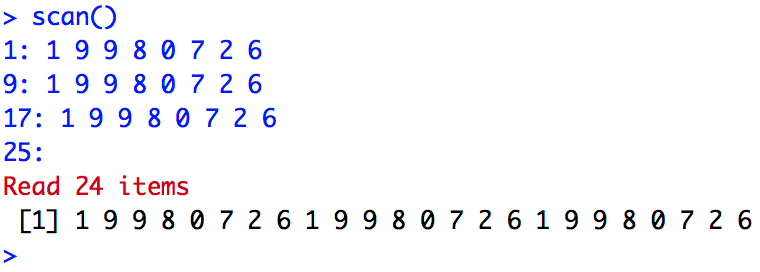

## Progressions and Sequences

An arithmetic progression is a succession of numbers such that the **difference**, \(d\), of any pair of successive terms in the sequence is constant. \[a_n = a_1 + (n-1) \ cdot d\]

- `seq (a, b, by=d)`: to generate an [arithmetic progression](https://es.wikipedia.org/wiki/ArhythmicProgression) of difference \(d\) that starts in \(to\) up get to \(b\)
- `seq (a, b, length.out=n)`: define arithmetic progression of length \(n\) ranging from \(a\) to \(b\) with difference \(d\). Therefore \(d = (b-a) / (n-1)\)
- `seq (a, by= d, length.out=n)`: define the arithmetic progression of length \(n\) and difference \(d\) starting in \(a\)
- `a:b`: define the sequence of consecutive numbers ** (\(\mathbb{Z}\)) between two numbers \(a\) and \(b\)

## Example of sequence

- This is an example of a sequence 5, 8.5, 12, 15.5, 19, 22.5, 26, 29.5, 33, 36.5, 40, 43.5, 47, 50.5, 54, 57.5
- If we want a sequence of **n** lengh we can use 5, 14.1666667, 23.3333333, 32.5, 41.6666667, 50.8333333, 60
- If we want to start in n number and have a determinate lenght with n step we use 5, 8, 11, 14, 17, 20, 23

## Sequences Exercises

- Numbers sequence from 1 ot 20: 1, 2, 3, 4, 5, 6, 7, 8, 9, 10, 11, 12, 13, 14, 15, 16, 17, 18, 19, 20
- First 20 pair numbers: 2, 4, 6, 8, 10, 12, 14, 16, 18, 20, 22, 24, 26, 28, 30, 32, 34, 36, 38, 40
- 30 equidistant numbers bettwen 17 and 98 with 4 significative decimals: [1] 17.0000 19.7931 22.5862 25.3793 28.1724 30.9655 33.7586 36.5517 [9] 39.3448 42.1379 44.9310 47.7241 50.5172 53.3103 56.1034 58.8966 [17] 61.6897 64.4828 67.2759 70.0690 72.8621 75.6552 78.4483 81.2414 [25] 84.0345 86.8276 89.6207 92.4138 95.2069 98.0000

## Example of vector

This is another example to generate a vector, c is also named as concatenation:

```r
c(rep(pi, 5), 5:10, -7) -> x
x
```

```
 [1]  3.141593  3.141593  3.141593  3.141593  3.141593  5.000000  6.000000
 [8]  7.000000  8.000000  9.000000 10.000000 -7.000000
```

```r
c(0, x, 10, x, 20)
```

```
 [1]  0.000000  3.141593  3.141593  3.141593  3.141593  3.141593  5.000000
 [8]  6.000000  7.000000  8.000000  9.000000 10.000000 -7.000000 10.000000
[15]  3.141593  3.141593  3.141593  3.141593  3.141593  5.000000  6.000000
[22]  7.000000  8.000000  9.000000 10.000000 -7.000000 20.000000
```

## Functions

When we want to apply a function to each of the elements of a data vector, the `sapply` function saves us having to program with loops in `R`:

- `sapply(vector_name, FUN = function_name)`: to apply this function to all vector elements
- `sqrt(x)`: Calculate a new vector with the square roots of each of the elements of the vector \(x\)

## Example of use sapply function

```r
x <- 1:10
sapply(x, FUN = function(w){sqrt(w)})
```

```
 [1] 1.000000 1.414214 1.732051 2.000000 2.236068 2.449490 2.645751
 [8] 2.828427 3.000000 3.162278
```

```r
sapply(x, function(w)sqrt(w))
```

```
 [1] 1.000000 1.414214 1.732051 2.000000 2.236068 2.449490 2.645751
 [8] 2.828427 3.000000 3.162278
```

## Functions

Given a vector of data \(x\) we can calculate many statistical measures about it:

- `length(x)`: Calculate the length of the vector \(x\)
- `max(x)`: calculates the maximum of the vector \(x\)
- `min(x)`: Calculate the minimum of the vector \(x\)
- `sum(x)`: calculates the sum of the entries of the vector \(x\)
- `prod(x)`: Calculate the product of the vector entries \(x\)

## Functions

- `mean(x)`: calculates the arithmetic mean of the entries in the vector \(x\)
- `diff(x)`: calculates the vector formed by the successive differences between entries of the original vector \(x\)
- `cumsum(x)`: calculates the vector formed by the cumulative sums of the original vector entries \(x\)
  - Allows to define sequences described by summation
  - Each entry of `cumsum(x)` is the sum of the \(x\) entries up to its position

## Functions

```r
square_fun = function(x){x^2}
v = c(1,2,3,4,5,6)
sapply(v, FUN = square_fun)
```

```
[1]  1  4  9 16 25 36
```

```r
mean(v)
```

```
[1] 3.5
```

```r
cumsum(v)
```

```
[1]  1  3  6 10 15 21
```

## Order

- `sort(x)`: order the vector in natural order of the objects that form it: the increasing numerical order, alphabetical order …
- `rev(x)`: invert the order of the vector elements \(x\)

```r
v = c(1,7,5,2,4,6,3)
sort(v)
```

```
[1] 1 2 3 4 5 6 7
```

```r
rev(v)
```

```
[1] 3 6 4 2 5 7 1
```

## Order Exercises

```r
v = c(1,7,5,2,4,6,3)
s = sort(v)
rev(s)
```

[1] 7 6 5 4 3 2 1

```r
v = c(1,7,5,2,4,6,3)
sort(v, decreasing = TRUE)
```

[1] 7 6 5 4 3 2 1

```r
v = c(1,7,5,2,4,6,3)
s = rev(v)
sort(s)
```

[1] 1 2 3 4 5 6 7

## Subvectors

- `vector[i]`: gives the \(i\) -th entry of the vector
  - R indexes start at 1
  - `vector[length(vector)]`: gives us the last entry of the vector
  - `vector[a:b]`: if \(a\) and \(b\) are two natural numbers, the subvector gives us with the entries of the original vector that go from the \(to\)-th position until the \(b\)-th.
  - `vector [-i]`: if \(i\) is a number, this subvector is made up of all the entries of the original vector except the \(i\) -th entry. If \(i\) turns out to be a vector, then it is an index vector and creates a new vector with the entries of the original vector, whose indexes belong to \(i\)
  - `vector[-x]`: if \(x\) is a vector (of indices), then this is the complement of vector [\(x\)]

## Subvectors

- Also has logic operators:
  - `==`: =
  - `!=`: \(\neq\)
  - `>=`: \(\ge\)
  - `<=`: \(\le\)
  - `<`: \(<\)
  - `>`: \(>\)
  - `!`: NO logic
  - `&`: AND logic
  - `|`: OR logic

## Subvectors

```r
v = c(14,5,6,19,32,0,8)
v[2]
```

```
[1] 5
```

```r
v[-c(3,5)]
```

```
[1] 14  5 19  0  8
```

```r
v[v != 19 & v>15]
```

```
[1] 32
```

## Subvectors

```r
w = seq(3, 50, by = 3.5)
w
```

```
 [1]  3.0  6.5 10.0 13.5 17.0 20.5 24.0 27.5 31.0 34.5 38.0 41.5 45.0 48.5
```

```r
w[4:8]
```

```
[1] 13.5 17.0 20.5 24.0 27.5
```

```r
w[8:4]
```

```
[1] 27.5 24.0 20.5 17.0 13.5
```

```r
w[seq(2, length(w), by = 2)]
```

```
[1]  6.5 13.5 20.5 27.5 34.5 41.5 48.5
```

## Subvectors

```r
w[seq(1, length(w), by = 2)]
```

```
[1]  3 10 17 24 31 38 45
```

```r
w[-seq(2, length(w), by = 2)]
```

```
[1]  3 10 17 24 31 38 45
```

```r
w[(length(w)-2):length(w)]
```

```
[1] 41.5 45.0 48.5
```

```r
w[c(1,5,6)]
```

```
[1]  3.0 17.0 20.5
```

## Subvectors

```r
w[w>30]
```

```
[1] 31.0 34.5 38.0 41.5 45.0 48.5
```

```r
w[w>20 & w<40]
```

```
[1] 20.5 24.0 27.5 31.0 34.5 38.0
```

```r
w[w!=3 & w!=17]
```

```
 [1]  6.5 10.0 13.5 20.5 24.0 27.5 31.0 34.5 38.0 41.5 45.0 48.5
```

```r
w[w<10|w>40]
```

```
[1]  3.0  6.5 41.5 45.0 48.5
```

## Subvectors

```r
w[w>=10]
```

```
 [1] 10.0 13.5 17.0 20.5 24.0 27.5 31.0 34.5 38.0 41.5 45.0 48.5
```

```r
w[w>10]
```

```
 [1] 13.5 17.0 20.5 24.0 27.5 31.0 34.5 38.0 41.5 45.0 48.5
```

```r
w[!w<10]
```

```
 [1] 10.0 13.5 17.0 20.5 24.0 27.5 31.0 34.5 38.0 41.5 45.0 48.5
```

```r
w[w%%2==0]
```

```
[1] 10 24 38
```

```r
w[w%%2==1]
```

```
[1]  3 17 31 45
```

```r
w>30
```

```
 [1] FALSE FALSE FALSE FALSE FALSE FALSE FALSE FALSE  TRUE  TRUE  TRUE
[12]  TRUE  TRUE  TRUE
```

## Subvectors

```r
w[w%%2==1]
```

```
[1]  3 17 31 45
```

```r
w>30
```

```
 [1] FALSE FALSE FALSE FALSE FALSE FALSE FALSE FALSE  TRUE  TRUE  TRUE
[12]  TRUE  TRUE  TRUE
```

## Subvectors

If we evaluate one vector in another vector, this will evaluate the **position** that meet the condition, also just can be possible if the two vectors has the same length

```r
x = c(1,7,4,2,4,8,9,2,0)
y = c(5,2,-3,-7,-1,4,-2,7,1)
x
y>0
x[y>0]
```

```
[1] 1 7 4 2 4 8 9 2 0
[1]  TRUE  TRUE FALSE FALSE FALSE  TRUE FALSE  TRUE  TRUE
[1] 1 7 8 2 0
```

## Conditional

- `which(x meets condition)`: to obtain the indexes of the \(x\) vector entries that satisfy the given condition
- `which.min(x)`: gives us the first position in which the vector \(x\) takes its minimum value
- `which(x==min(x))`: gives all the positions in which the vector \(x\) takes its minimum values
- `which.max(x)`: gives us the first position in which the vector \(x\) takes its maximum value
- `which(x ==max(x))`: gives all the positions in which the vector \(x\) takes its maximum values

## Conditional

if we use which inside the vector this will return the values, not the positions

```r
x
```

```
[1] 1 7 4 2 4 8 9 2 0
```

```r
which(x>4)
```

```
[1] 2 6 7
```

```r
x[which(x>4)]
```

```
[1] 7 8 9
```

```r
x[x>4]
```

```
[1] 7 8 9
```

## Conditional

The first one shows the positions and the second one shows the values that are in those positions

```r
x
which(x<5 | x%%2==0)
x[which(x<5 | x%%2==0)]
```

```
[1] 1 7 4 2 4 8 9 2 0
[1] 1 3 4 5 6 8 9
[1] 1 4 2 4 8 2 0
```

## Conditional

Display the location of the minimum value that is 0, \(which.min(x)\) show just the first value that is found, in this case there is just one 0 so \(which(x==min(x))\) will also show the 0

```r
x
which.min(x)
which(x==min(x))
```

```
[1] 1 7 4 2 4 8 9 2 0
[1] 9
[1] 9
```

## Conditional

```r
x = c(1, 7, 4, 2, 4, 8, 9, 2, 0, 9)
which.max(x)
which(x==max(x))
```

```
[1] 7
[1]  7 10
```

## NA Values

Sometimes vectors has NA values so that we need to attack this cases in the next form:

Dont taking in to account the NA values with \(na.rm=true\), this is not recommended.

```r
x = c(1, 7, 4, 2, 4, 8, 9, 2, 0, NA, NA, NA, 9)
sum(x, na.rm = TRUE)
mean(x, na.rm =TRUE)
```

```
[1] 46
[1] 4.6
```

## NA Values

We will use instead the function \(is.na(somevector)\), this will show us the possition of the **NA values** with a TRUE statement

```r
x
is.na(x)
```

```
 [1]  1  7  4  2  4  8  9  2  0 NA NA NA  9
 [1] FALSE FALSE FALSE FALSE FALSE FALSE FALSE FALSE FALSE  TRUE  TRUE
[12]  TRUE FALSE
```

Now we can determinate the position with:

```r
which(is.na(x))
```

```
[1] 10 11 12
```

## NA Values

If we want to know the values (already assuming that will show NA) , this are already the values not the positions

```r
x[which(is.na(x))]
```

```
[1] NA NA NA
```

Now lets write the mean of this vector to fill the NA, this is more recommended than delate the NA

```r
y = x
y[which(is.na(y))] = mean(y, na.rm=TRUE)
y
```

```
 [1] 1.0 7.0 4.0 2.0 4.0 8.0 9.0 2.0 0.0 4.6 4.6 4.6 9.0
```

## NA Values

Another way to doesnt take in to account the NA values is with the function:

```r
x
```

```
 [1]  1  7  4  2  4  8  9  2  0 NA NA NA  9
```

```r
x_clean = na.omit(x)
x_clean
```

```
 [1] 1 7 4 2 4 8 9 2 0 9
attr(,"na.action")
[1] 10 11 12
attr(,"class")
[1] "omit"
```

## NA Values

This will generate attributes, that can be delated with:

```r
x_clean
```

```
 [1] 1 7 4 2 4 8 9 2 0 9
attr(,"na.action")
[1] 10 11 12
attr(,"class")
[1] "omit"
```

```r
attr(x_clean, "na.action") = NULL
attr(x_clean, "class") = NULL
x_clean
```

```
 [1] 1 7 4 2 4 8 9 2 0 9
```

## Factors

Factor: it’s like a vector, but with a richer internal structure that allows it to be used to classify observations

- `levels`: factor attribute. Each element of the factor is equal to one level. The levels classify the inputs of the factor. They are sorted alphabetically
- To define a factor, we must first define a vector and transform it by means of one of the functions `factor()` or `as.factor()`.

```r
gender = c("M", "F", "M", "F", "F", "F", "F", "M", "M")
gender.fact = factor(gender)
gender.fact
```

```
[1] M F M F F F F M M
Levels: F M
```

## Factors

Another way to express a factor

```r
gender.fact2 = as.factor(gender)
gender.fact2
```

```
[1] M F M F F F F M M
Levels: F M
```

## Modify a factors

Is possible to add more levels

```r
gender.fact3 = factor(gender, levels = c("M", "F", "B"))
gender.fact3
```

```
[1] M F M F F F F M M
Levels: M F B
```

## Modify a factors

Is possible to add labels

```r
gender.fact4 = factor(gender, levels = c("M", "F", "B"), labels = c("Male", "Female", "Bisexual"))
gender.fact4
```

```
[1] Male   Female Male   Female Female Female Female Male   Male
Levels: Male Female Bisexual
```

## Check levels of a factor

To check the levels that hold a factor

```r
levels(gender.fact)
```

```
[1] "F" "M"
```

```r
levels(gender.fact4)
```

```
[1] "Male"     "Female"   "Bisexual"
```

## Modify level of a factor

To check the levels that hold a factor

```r
levels(gender.fact4) = c("Male", "Female", "Bi")
gender.fact4
```

```
[1] Male   Female Male   Female Female Female Female Male   Male
Levels: Male Female Bi
```

## Example

```r
note = c(1,2,3,4,4,3,4,3,2,1,2,3,4)
note.fact = factor(note)
note.fact
```

```
 [1] 1 2 3 4 4 3 4 3 2 1 2 3 4
Levels: 1 2 3 4
```

## Example

```r
levels(note.fact)
```

```
[1] "1" "2" "3" "4"
```

```r
levels(note.fact) = c("fail", "good", "very good", "excellent")
note.fact
```

```
 [1] fail      good      very good excellent excellent very good excellent
 [8] very good good      fail      good      very good excellent
Levels: fail good very good excellent
```

## Example

Is possible to group different levels

```r
note
```

```
 [1] 1 2 3 4 4 3 4 3 2 1 2 3 4
```

```r
levels(note.fact) = c("fail", "good", "good", "good")
note.fact
```

```
 [1] fail good good good good good good good good fail good good good
Levels: fail good
```

## Ordered factor

Ordered factor. It is a factor where the levels follow an order

- `ordered (vector, levels = ...)`: function that defines an ordered factor and has the same parameters as factor

## Ordered factor

```r
note
```

```
 [1] 1 2 3 4 4 3 4 3 2 1 2 3 4
```

```r
ordered(note, labels = c("fail", "good", "very good", "excellent"))
```

```
 [1] fail      good      very good excellent excellent very good excellent
 [8] very good good      fail      good      very good excellent
Levels: fail < good < very good < excellent
```

## Ordered factor example

```r
fac = factor(c(1,1,1,2,2,3,2,4,1,3,3,4,2,3,4,4),
       levels = c(1,2,3,4), labels = c("Sus","Apr","Not","Exc"))
fac
```

```
 [1] Sus Sus Sus Apr Apr Not Apr Exc Sus Not Not Exc Apr Not Exc Exc
Levels: Sus Apr Not Exc
```

```r
facOrd = ordered(c(1,1,1,2,2,3,2,4,1,3,3,4,2,3,4,4),
       levels = c(1,2,3,4), labels = c("Sus","Apr","Not","Exc"))
facOrd
```

```
 [1] Sus Sus Sus Apr Apr Not Apr Exc Sus Not Not Exc Apr Not Exc Exc
Levels: Sus < Apr < Not < Exc
```

## Lists

List. List consisting of different objects, not necessarily of the same type, each with an internal name

## Get information of one list

If we want to access to one component of the list is necessary to use the character \(\$\)

```r
x = c(1,-2,3,4,-5,6,7,-8,-9,0)
L = list(name = "Temperature", vector = x, mean_list = mean(x), summation = cumsum(x))
L
```

```
$name
[1] "Temperature"

$vector
 [1]  1 -2  3  4 -5  6  7 -8 -9  0

$mean_list
[1] -0.3

$summation
 [1]  1 -1  2  6  1  7 14  6 -3 -3
```

```r
L$mean_list
```

```
[1] -0.3
```

## Get information of one list

Also with the position, it needs to have double bracket, we will get the vector in this case

```r
L[[2]]
```

```
 [1]  1 -2  3  4 -5  6  7 -8 -9  0
```

## Get information of one list

- `str(list)`: to know the intern structure of one list
- `names(list)`: to know the names of the list

```r
str(L) # get the structure of the list
```

```
List of 4
 $ name     : chr "Temperature"
 $ vector   : num [1:10] 1 -2 3 4 -5 6 7 -8 -9 0
 $ mean_list: num -0.3
 $ summation: num [1:10] 1 -1 2 6 1 7 14 6 -3 -3
```

```r
names(L)
```

```
[1] "name"      "vector"    "mean_list" "summation"
```

## Matrix

## How to define them

- `matrix (vector, nrow = n, byrow = logical_value)`: to define a matrix of $ n $ rows formed by the entries of the vector
  - `nrow`: number of rows
  - `byrow`: if it is equal to TRUE, the matrix is constructed by rows; if it is equal to FALSE (default value), it is constructed by columns. -`ncol`: number of columns (can be used instead of nrow)
  - R shows the matrices indicating as [$ i, $] the $ i $ -th row and [$, j $] the $ j $ -th column
- All entries in an array must be of the same type of data

## Matrix example

```r
M = matrix(1:12, nrow= 4)
M
```

```
     [,1] [,2] [,3]
[1,]    1    5    9
[2,]    2    6   10
[3,]    3    7   11
[4,]    4    8   12
```

```r
M = matrix(1:12, nrow= 4, byrow = TRUE)
M
```

```
     [,1] [,2] [,3]
[1,]    1    2    3
[2,]    4    5    6
[3,]    7    8    9
[4,]   10   11   12
```

## Matrix example

```r
M = matrix(1:12, nrow= 3)
M
```

```
     [,1] [,2] [,3] [,4]
[1,]    1    4    7   10
[2,]    2    5    8   11
[3,]    3    6    9   12
```

## Matrix example

If we write a number of rows that is not mulptiple of the data lenght it will filled with the begging numbers

```r
M = matrix(1:12, nrow= 5)
```

```
Warning in matrix(1:12, nrow = 5): data length [12] is not a sub-multiple
or multiple of the number of rows [5]
```

```r
M
```

```
     [,1] [,2] [,3]
[1,]    1    6   11
[2,]    2    7   12
[3,]    3    8    1
[4,]    4    9    2
[5,]    5   10    3
```

## Matrix example

If we just have one data

```r
M = matrix(1, nrow= 4, ncol = 6)
M
```

```
     [,1] [,2] [,3] [,4] [,5] [,6]
[1,]    1    1    1    1    1    1
[2,]    1    1    1    1    1    1
[3,]    1    1    1    1    1    1
[4,]    1    1    1    1    1    1
```

## Matrix exercise

- How would you define a constant matrix? That is, how would you define a \(A\) matrix such that \(\forall\ i=1,...,n; j = 1,...,m\), \(a_{i,j}=k\) where \(k\in\mathbb{R}\)? Since R does not admit unknowns, test for the specific case \(n = 3, m = 5, k = 0\)

```r
matrix(0, nrow = 3, ncol = 5)
```

```
     [,1] [,2] [,3] [,4] [,5]
[1,]    0    0    0    0    0
[2,]    0    0    0    0    0
[3,]    0    0    0    0    0
```

## Matrix exercise

- With the vector vec = (1,2,3,4,5,6,7,8,9,10,11,12) create a matrix

```r
vec <- c(1,2,3,4,5,6,7,8,9,10,11,12)
m_example <- matrix(vec, nrow = 3)
m_example
```

```
     [,1] [,2] [,3] [,4]
[1,]    1    4    7   10
[2,]    2    5    8   11
[3,]    3    6    9   12
```

## How to build a matrix with other functions

- `rbind (vector1, vector2, ...)`: construct the array of rows vector1, vector2, …
- `cbind (vector1, vector2, ...)`: construct the column matrix vector1, vector2, …
  - Vectors must have the same length
  - It also serves to add columns (rows) to an array or concatenate columns (rows) matrices with the same number of rows (columns)
- `diag (vector)`: to construct a diagonal matrix with a given vector
  - If we apply diag to a \(n\) number, it produces an identity matrix of order \(n\)

## How to build a matrix with other functions

Here we added the rows or we can also generate another matrix

```r
M = matrix(1:12, nrow= 3)
rbind(M, c(1,2,3,4), c(5,6,7,8))
```

```
     [,1] [,2] [,3] [,4]
[1,]    1    4    7   10
[2,]    2    5    8   11
[3,]    3    6    9   12
[4,]    1    2    3    4
[5,]    5    6    7    8
```

```r
rbind(c(1,2,3,4), c(5,6,7,8))
```

```
     [,1] [,2] [,3] [,4]
[1,]    1    2    3    4
[2,]    5    6    7    8
```

## How to build a matrix with other functions

Here we added the vectors in columns

```r
cbind(c(1,2,3,4), c(5,6,7,8))
```

```
     [,1] [,2]
[1,]    1    5
[2,]    2    6
[3,]    3    7
[4,]    4    8
```

## How to build a matrix with other functions

```r
diag(5, nrow=3)
```

```
     [,1] [,2] [,3]
[1,]    5    0    0
[2,]    0    5    0
[3,]    0    0    5
```

## Submatrix

- `matrix [i,j]`: indicates the entry (\(i,j\)) of the matrix, being \(i,j\in\mathbb{N}\). If \(i\) and \(j\) are index vectors, we will be defining the submatrix with the rows belonging to the vector \(i\) and columns belonging to the vector \(j\)
- `matrix [i,]`: indicates the $ i $ -th row of the matrix, being \(i\in\mathbb{N}\)
- `matrix [, j]`: indicates the $ j $ -th column of the being \(j\in\mathbb{N}\)
  - If \(i\) (\(j\)) is an index vector, we will be defining the submatrix with the rows (columns) belonging to the vector \(i\) (\(j\))

## Submatrix

```r
M
```

```
     [,1] [,2] [,3] [,4]
[1,]    1    4    7   10
[2,]    2    5    8   11
[3,]    3    6    9   12
```

```r
M[2,3]
```

```
[1] 8
```

```r
M[2,]
```

```
[1]  2  5  8 11
```

```r
M[,2]
```

```
[1] 4 5 6
```

## Submatrix

```r
M
```

```
     [,1] [,2] [,3] [,4]
[1,]    1    4    7   10
[2,]    2    5    8   11
[3,]    3    6    9   12
```

```r
M[c(2,3), 1:2]
```

```
     [,1] [,2]
[1,]    2    5
[2,]    3    6
```

## Functions

- `diag(matrix)`: to obtain the diagonal of the matrix
- `nrow(matrix)`: returns the number of rows in the matrix
- `ncol(matrix)`: returns the number of columns in the matrix
- `dim(matrix)`: returns the dimensions of the matrix
- `sum(matrix)`: we get the sum of all the entries in the matrix
- `prod(matrix)`: we get the product of all the entries in the matrix
- `mean(matrix)`: we get the arithmetic mean of all the entries in the matrix

## Functions example

```r
M
```

```
     [,1] [,2] [,3] [,4]
[1,]    1    4    7   10
[2,]    2    5    8   11
[3,]    3    6    9   12
```

```r
diag(M)
```

```
[1] 1 5 9
```

```r
nrow(M)
```

```
[1] 3
```

```r
ncol(M)
```

```
[1] 4
```

## Functions

- `colSums(matrix)`: we obtain the sums by columns of the matrix
- `rowSums(matrix)`: we obtain the sums by rows of the matrix
- `colMeans(matrix)`: we obtain the arithmetic means by columns of the matrix
- `rowMeans(matrix)`: we obtain the arithmetic means by rows of the matrix

## Functions example

```r
M
```

```
     [,1] [,2] [,3] [,4]
[1,]    1    4    7   10
[2,]    2    5    8   11
[3,]    3    6    9   12
```

```r
colSums(M)
```

```
[1]  6 15 24 33
```

```r
rowSums(M)
```

```
[1] 22 26 30
```

```r
colMeans(M)
```

```
[1]  2  5  8 11
```

## Functions example

Given the matrix \[A = \begin{pmatrix} 1 & 4 & 7\\ 2 & 5 & 8\\ 3 & 6 & 9 \end{pmatrix}\]

```r
A = matrix(c(1,2,3,4,5,6,7,8,9), ncol = 3)
dim(A)
```

```
[1] 3 3
```

```r
diag(A)
```

```
[1] 1 5 9
```

## Función apply()

- `apply (matrix, MARGIN = ..., FUN = function)`: to apply other functions to the rows or columns of an array
  - `MARGIN`: must be 1 if we want to apply the function by rows; 2 if we want to apply it by columns; or c (1,2) if we want to apply it to each entry

[output not shown]

```r
apply(A, MARGIN = 1, FUN = sqrt_sum_function)
```

```
[1]  8.124038  9.643651 11.224972
```

```r
apply(A, MARGIN = c(1,2), FUN = function(argA){argA^2})
```

```
     [,1] [,2] [,3]
[1,]    1   16   49
[2,]    4   25   64
[3,]    9   36   81
```

## Note

**sapply** casts the data frame, to a list or vector before operating on it, **apply** casts the data frame to a matrix. Since matrices cannot have mixed types and there is at least one column with non-numeric data, then everything becomes character data.

## Función apply()

```r
cuadrado = function(x){x^2}
A
```

```
     [,1] [,2] [,3]
[1,]    1    4    7
[2,]    2    5    8
[3,]    3    6    9
```

```r
apply(A, MARGIN = c(1,2), FUN = cuadrado)
```

```
     [,1] [,2] [,3]
[1,]    1   16   49
[2,]    4   25   64
[3,]    9   36   81
```

```r
apply(A, MARGIN = 1, FUN = sum)
```

```
[1] 12 15 18
```

```r
apply(A, MARGIN = 2, FUN = sum)
```

```
[1]  6 15 24
```

## Función apply()

```r
A
```

```
     [,1] [,2] [,3]
[1,]    1    4    7
[2,]    2    5    8
[3,]    3    6    9
```

```r
apply(A, MARGIN = 1, FUN = sum)
```

```
[1] 12 15 18
```

```r
apply(A, MARGIN = 2, FUN = sum)
```

```
[1]  6 15 24
```

## Operations

- `t(matrix)`: to obtain the matrix transpose
- `+`: to add matrices
- `*`: for the product of a scalar by a matrix
- `% *%`: to multiply matrices
- `mtx.exp(matrix,n)`: to raise the matrix to \(n\)
  - From the `Biodem` package
- Does not calculate the exact powers, approximates them
- `%%`: to raise matrices
  - From the `expm` package
- Does not calculate the exact powers, approximates them

## Transpose of a matrix

```r
M
```

```
     [,1] [,2] [,3] [,4]
[1,]    1    4    7   10
[2,]    2    5    8   11
[3,]    3    6    9   12
```

```r
t(M)
```

```
     [,1] [,2] [,3]
[1,]    1    2    3
[2,]    4    5    6
[3,]    7    8    9
[4,]   10   11   12
```

## Multiply two matrix

We will multiply \(W * W\), note this is not the same as \(W^2\)

```r
W
```

```
     [,1] [,2] [,3]
[1,]    1    4    7
[2,]    2    5    8
[3,]    3    6    9
```

```r
W%*%W
```

```
     [,1] [,2] [,3]
[1,]   30   66  102
[2,]   36   81  126
[3,]   42   96  150
```

## Operations exercise

If \(A = \begin{pmatrix} 2 & 0 & 2\\ 1 & 2 & 3\\ 0 & 1 & 3 \end{pmatrix}\) and \(B = \begin{pmatrix} 3 & 2 & 1\\ 1 & 0 & 0\\ 1 & 1 & 1 \end{pmatrix}\), do the next operations \(A*B\), \(A^2\) and \(B^3\)

## Operations exercise

A*B

```r
eA = rbind(c(2,0,2), c(1,2,3), c(0,1,3))
eB = rbind(c(3,2,1), c(1,0,0), c(1,1,1))
eA%*%eB
```

```
     [,1] [,2] [,3]
[1,]    8    6    4
[2,]    8    5    4
[3,]    4    3    3
```

## Operations exercise

```r
eA^2
```

```
     [,1] [,2] [,3]
[1,]    4    0    4
[2,]    1    4    9
[3,]    0    1    9
```

```r
eB^3
```

```
     [,1] [,2] [,3]
[1,]   27    8    1
[2,]    1    0    0
[3,]    1    1    1
```